# Part I - (Airline Data Exploration)

## Introduction

> This dataset contains scheduled and actual departure and arrival times reported by certified U.S. air carriers, arrival and departure delays, and reasons for delays, from 1987 to 2020. The data is collected by the Office of Airline Information, Bureau of Transportation Statistics (BTS).

## Preliminary Wrangling

```python
# import all packages and set plots to be embedded inline
import numpy as np
import pandas as pd
import matplotlib.pyplot as plt
import seaborn as sb

%matplotlib inline
```

### Load Dataset

```python
# Loading the airline data
data = pd.read_csv("flights_data.csv")
```

### Check Shape

```python
data.shape
```

```
(27000, 110)
```

The dataset consists of 27000 rows and 110 columns. Some columns might be unneccessary on this analysis.

```python
data.head()
```

|  | Unnamed: 0 | Year | Quarter | Month | DayofMonth | DayOfWeek | FlightDate | Reporting_Airline | DOT_ID_Reporting_Airline | IATA_CODE_Reporting_Airline | ... | Div4WheelsOff | Div4TailNum | Div5Airport | Div5AirportID | Div5AirportSeqID | Div5WheelsOn | Div5TotalGTime | Div5LongestGTime | Div5WheelsOff | Div5TailNum |
| --- | --- | --- | --- | --- | --- | --- | --- | --- | --- | --- | --- | --- | --- | --- | --- | --- | --- | --- | --- | --- | --- |
| 0 | 1295781 | 1998 | 2 | 4 | 2 | 4 | 1998-04-02 | AS | 19930 | AS | ... | NaN | NaN | NaN | NaN | NaN | NaN | NaN | NaN | NaN | NaN |
| 1 | 1125375 | 2013 | 2 | 5 | 13 | 1 | 2013-05-13 | EV | 20366 | EV | ... | NaN | NaN | NaN | NaN | NaN | NaN | NaN | NaN | NaN | NaN |
| 2 | 118824 | 1993 | 3 | 9 | 25 | 6 | 1993-09-25 | UA | 19977 | UA | ... | NaN | NaN | NaN | NaN | NaN | NaN | NaN | NaN | NaN | NaN |
| 3 | 634825 | 1994 | 4 | 11 | 12 | 6 | 1994-11-12 | HP | 19991 | HP | ... | NaN | NaN | NaN | NaN | NaN | NaN | NaN | NaN | NaN | NaN |
| 4 | 1888125 | 2017 | 3 | 8 | 17 | 4 | 2017-08-17 | UA | 19977 | UA | ... | NaN | NaN | NaN | NaN | NaN | NaN | NaN | NaN | NaN | NaN |

5 rows × 110 columns

### Deleting unwanted columns, so that we can have a dataset that has few columns and neccessary columns for the analysis.

```python
# creating a list of column name that i want to keep

columns = ['Unnamed: 0','Year','Quarter','Month','DayofMonth','DayOfWeek','FlightDate','Reporting_Airline',
        'Origin','Dest','DepTime','DepDelay','ArrTime','ArrDelay','Cancelled','CancellationCode','Diverted',
        'AirTime','Flights','Distance','CarrierDelay','WeatherDelay','NASDelay','SecurityDelay','LateAircraftDelay']

# creating a new dataset with only the selected columns from the origanal dataset

f_data = data[columns]
```

```python
# checking the shape of the new dataset
f_data.shape
```

```
(27000, 25)
```

The dataset now consist of 27000 rows and 25 columns

### The 'Unnamed: 0' column has to be renamed to a meaningful name

```python
# renaming the column
f_data = f_data.rename(columns = {'Unnamed: 0':'ID'})
```

```python
f_data.sample(30)
```

|  | ID | Year | Quarter | Month | DayofMonth | DayOfWeek | FlightDate | Reporting_Airline | Origin | Dest | ... | CancellationCode | Diverted | AirTime | Flights | Distance | CarrierDelay | WeatherDelay | NASDelay | SecurityDelay | LateAircraftDelay |
| --- | --- | --- | --- | --- | --- | --- | --- | --- | --- | --- | --- | --- | --- | --- | --- | --- | --- | --- | --- | --- | --- |
| 14336 | 1201638 | 2016 | 4 | 12 | 3 | 6 | 2016-12-03 | DL | LGA | DTW | ... | NaN | 0.0 | 84.0 | 1.0 | 502.0 | NaN | NaN | NaN | NaN | NaN |
| 10673 | 133725 | 2007 | 4 | 10 | 10 | 3 | 2007-10-10 | B6 | FLL | JFK | ... | NaN | 0.0 | 135.0 | 1.0 | 1069.0 | 0.0 | 0.0 | 52.0 | 0.0 | 0.0 |
| 484 | 1685982 | 2017 | 2 | 6 | 19 | 1 | 2017-06-19 | WN | MDW | DEN | ... | NaN | 0.0 | 125.0 | 1.0 | 895.0 | 35.0 | 0.0 | 0.0 | 0.0 | 19.0 |
| 942 | 1821907 | 2014 | 2 | 6 | 15 | 7 | 2014-06-15 | EV | SHV | ATL | ... | NaN | 0.0 | 107.0 | 1.0 | 551.0 | 4.0 | 0.0 | 24.0 | 0.0 | 0.0 |
| 17567 | 393409 | 2010 | 2 | 6 | 28 | 1 | 2010-06-28 | FL | ATL | BOS | ... | NaN | 0.0 | 125.0 | 1.0 | 946.0 | NaN | NaN | NaN | NaN | NaN |
| 10446 | 255726 | 2018 | 2 | 6 | 18 | 1 | 2018-06-18 | EV | IAH | PNS | ... | NaN | 0.0 | 78.0 | 1.0 | 489.0 | NaN | NaN | NaN | NaN | NaN |
| 21564 | 433814 | 2009 | 3 | 8 | 16 | 7 | 2009-08-16 | US | MIA | CLT | ... | NaN | 0.0 | 98.0 | 1.0 | 650.0 | NaN | NaN | NaN | NaN | NaN |
| 3820 | 1000895 | 2010 | 3 | 7 | 15 | 4 | 2010-07-15 | US | EWR | CLT | ... | NaN | 0.0 | 72.0 | 1.0 | 529.0 | NaN | NaN | NaN | NaN | NaN |
| 24334 | 427333 | 2016 | 4 | 11 | 29 | 2 | 2016-11-29 | AA | SJU | DFW | ... | NaN | 0.0 | 281.0 | 1.0 | 2165.0 | NaN | NaN | NaN | NaN | NaN |
| 3379 | 318686 | 1991 | 2 | 5 | 19 | 7 | 1991-05-19 | DL | SDF | DAY | ... | NaN | 0.0 | NaN | 1.0 | 144.0 | NaN | NaN | NaN | NaN | NaN |
| 10879 | 1129671 | 2004 | 3 | 7 | 23 | 5 | 2004-07-23 | AA | DFW | MSY | ... | NaN | 0.0 | 64.0 | 1.0 | 448.0 | 20.0 | 0.0 | 0.0 | 0.0 | 0.0 |
| 25166 | 1283641 | 2001 | 1 | 3 | 16 | 5 | 2001-03-16 | CO | IAH | MSP | ... | NaN | 0.0 | 134.0 | 1.0 | 1034.0 | NaN | NaN | NaN | NaN | NaN |
| 12070 | 134760 | 2005 | 4 | 11 | 17 | 4 | 2005-11-17 | WN | OAK | SEA | ... | NaN | 0.0 | 105.0 | 1.0 | 671.0 | 0.0 | 0.0 | 8.0 | 0.0 | 15.0 |
| 23629 | 826146 | 1990 | 4 | 12 | 17 | 1 | 1990-12-17 | US | SFO | SNA | ... | NaN | 0.0 | NaN | 1.0 | 372.0 | NaN | NaN | NaN | NaN | NaN |
| 18779 | 744976 | 1991 | 4 | 12 | 9 | 1 | 1991-12-09 | WN | LBB | ELP | ... | NaN | 0.0 | NaN | 1.0 | 295.0 | NaN | NaN | NaN | NaN | NaN |
| 8099 | 501621 | 2009 | 2 | 4 | 28 | 2 | 2009-04-28 | XE | EWR | DTW | ... | NaN | 0.0 | 89.0 | 1.0 | 487.0 | NaN | NaN | NaN | NaN | NaN |
| 9462 | 1957241 | 1992 | 3 | 7 | 27 | 1 | 1992-07-27 | HP | LAS | PHX | ... | NaN | 0.0 | NaN | 1.0 | 256.0 | NaN | NaN | NaN | NaN | NaN |
| 5344 | 107602 | 2006 | 4 | 12 | 14 | 4 | 2006-12-14 | CO | IAH | JFK | ... | NaN | 0.0 | 167.0 | 1.0 | 1417.0 | 0.0 | 0.0 | 179.0 | 0.0 | 0.0 |
| 15939 | 1500410 | 2011 | 3 | 7 | 14 | 4 | 2011-07-14 | DL | MSP | AUS | ... | NaN | 0.0 | 124.0 | 1.0 | 1042.0 | NaN | NaN | NaN | NaN | NaN |
| 24948 | 1650457 | 2014 | 1 | 1 | 19 | 7 | 2014-01-19 | MQ | DSM | ORD | ... | NaN | 0.0 | 52.0 | 1.0 | 299.0 | NaN | NaN | NaN | NaN | NaN |
| 25635 | 1878578 | 1999 | 3 | 9 | 5 | 7 | 1999-09-05 | UA | MIA | ORD | ... | NaN | 0.0 | 147.0 | 1.0 | 1197.0 | NaN | NaN | NaN | NaN | NaN |
| 26566 | 101840 | 1991 | 4 | 12 | 8 | 7 | 1991-12-08 | CO | ORD | EWR | ... | NaN | 0.0 | NaN | 1.0 | 719.0 | NaN | NaN | NaN | NaN | NaN |
| 11297 | 176522 | 1995 | 4 | 11 | 22 | 3 | 1995-11-22 | DL | FLL | BDL | ... | NaN | 0.0 | 161.0 | 1.0 | 1173.0 | NaN | NaN | NaN | NaN | NaN |
| 8978 | 1916618 | 2014 | 1 | 1 | 10 | 5 | 2014-01-10 | WN | ATL | HOU | ... | NaN | 0.0 | 126.0 | 1.0 | 696.0 | NaN | NaN | NaN | NaN | NaN |
| 15895 | 1434915 | 2003 | 1 | 1 | 13 | 1 | 2003-01-13 | NW | DTW | SAN | ... | NaN | 0.0 | 273.0 | 1.0 | 1956.0 | NaN | NaN | NaN | NaN | NaN |
| 3339 | 767462 | 1991 | 4 | 12 | 29 | 7 | 1991-12-29 | NW | MSP | MCI | ... | NaN | 0.0 | NaN | 1.0 | 393.0 | NaN | NaN | NaN | NaN | NaN |
| 17102 | 1237076 | 2015 | 2 | 4 | 1 | 3 | 2015-04-01 | EV | EWR | CVG | ... | NaN | 0.0 | 100.0 | 1.0 | 569.0 | NaN | NaN | NaN | NaN | NaN |
| 17613 | 1407792 | 2009 | 4 | 12 | 10 | 4 | 2009-12-10 | AA | DFW | DCA | ... | NaN | 0.0 | 122.0 | 1.0 | 1192.0 | 26.0 | 0.0 | 0.0 | 0.0 | 0.0 |
| 247 | 689318 | 2009 | 3 | 8 | 18 | 2 | 2009-08-18 | OH | CVG | GSO | ... | NaN | 0.0 | 59.0 | 1.0 | 330.0 | NaN | NaN | NaN | NaN | NaN |
| 9916 | 36175 | 2011 | 2 | 5 | 26 | 4 | 2011-05-26 | YV | BDL | IAD | ... | NaN | 0.0 | 58.0 | 1.0 | 326.0 | NaN | NaN | NaN | NaN | NaN |

30 rows × 25 columns

```python
f_data.info()
```

```
<class 'pandas.core.frame.DataFrame'>
RangeIndex: 27000 entries, 0 to 26999
Data columns (total 25 columns):
ID                   27000 non-null int64
Year                 27000 non-null int64
Quarter              27000 non-null int64
Month                27000 non-null int64
DayofMonth           27000 non-null int64
DayOfWeek            27000 non-null int64
FlightDate           27000 non-null object
Reporting_Airline    27000 non-null object
Origin               27000 non-null object
Dest                 27000 non-null object
DepTime              26557 non-null float64
DepDelay             26557 non-null float64
ArrTime              26517 non-null float64
ArrDelay             26498 non-null float64
Cancelled            27000 non-null float64
CancellationCode     250 non-null object
Diverted             27000 non-null float64
AirTime              21406 non-null float64
Flights              27000 non-null float64
Distance             27000 non-null float64
CarrierDelay         3057 non-null float64
WeatherDelay         3057 non-null float64
NASDelay             3057 non-null float64
SecurityDelay        3057 non-null float64
LateAircraftDelay    3057 non-null float64
dtypes: float64(14), int64(6), object(5)
memory usage: 5.1+ MB
```

### Checking for nulls

```python
f_data.isnull().sum()
```

```
ID                       0
Year                     0
Quarter                  0
Month                    0
DayofMonth               0
DayOfWeek                0
FlightDate               0
Reporting_Airline        0
Origin                   0
Dest                     0
DepTime                443
DepDelay               443
ArrTime                483
ArrDelay               502
Cancelled                0
CancellationCode     26750
Diverted                 0
AirTime               5594
Flights                  0
Distance                 0
CarrierDelay         23943
WeatherDelay         23943
NASDelay             23943
SecurityDelay        23943
LateAircraftDelay    23943
dtype: int64
```

Most of the columns have many null values and this can affect the results of the analysis

### Replacing the null values in the following columns:

CarrierDelay  
WeatherDelay  
NASDelay  
SecurityDelay  
LateAircraftDelay DepTime  
DepDelay  
ArrTime  
ArrDelay  
AirTime

```python
f_data['CarrierDelay'] = f_data['CarrierDelay'].fillna(0)
f_data['WeatherDelay'] = f_data['WeatherDelay'].fillna(0)
f_data['NASDelay'] = f_data['NASDelay'].fillna(0)
f_data['SecurityDelay'] = f_data['SecurityDelay'].fillna(0)
f_data['LateAircraftDelay'] = f_data['LateAircraftDelay'].fillna(0)
f_data['DepTime'] = f_data['DepTime'].fillna(0)
f_data['DepDelay'] = f_data['DepDelay'].fillna(0)
f_data['ArrTime'] = f_data['ArrTime'].fillna(0)
f_data['ArrDelay']  = f_data['ArrDelay'].fillna(0)
f_data['AirTime']  = f_data['AirTime'].fillna(0)
```

```python
# checking if the above code worked
f_data[['CarrierDelay','WeatherDelay','NASDelay','SecurityDelay','LateAircraftDelay', 'DepTime','DepDelay','ArrTime','ArrDelay', 'AirTime']].isnull().values.any()
```

```
False
```

### Checking for duplicates

```python
f_data.duplicated().sum()
```

```
0
```

No duplicates found

### Vissually exploring the data for all columns

```python
pd.set_option('max_columns', None)
f_data.sample(10)
```

|  | ID | Year | Quarter | Month | DayofMonth | DayOfWeek | FlightDate | Reporting_Airline | Origin | Dest | DepTime | DepDelay | ArrTime | ArrDelay | Cancelled | CancellationCode | Diverted | AirTime | Flights | Distance | CarrierDelay | WeatherDelay | NASDelay | SecurityDelay | LateAircraftDelay |
| --- | --- | --- | --- | --- | --- | --- | --- | --- | --- | --- | --- | --- | --- | --- | --- | --- | --- | --- | --- | --- | --- | --- | --- | --- | --- |
| 18812 | 854990 | 2011 | 3 | 9 | 5 | 1 | 2011-09-05 | CO | SAT | IAH | 1735.0 | 50.0 | 1833.0 | 46.0 | 0.0 | NaN | 0.0 | 39.0 | 1.0 | 191.0 | 0.0 | 0.0 | 0.0 | 0.0 | 46.0 |
| 17579 | 1046137 | 1992 | 4 | 11 | 21 | 6 | 1992-11-21 | US | PIT | EWR | 1401.0 | 16.0 | 1514.0 | 11.0 | 0.0 | NaN | 0.0 | 0.0 | 1.0 | 319.0 | 0.0 | 0.0 | 0.0 | 0.0 | 0.0 |
| 2828 | 710038 | 2001 | 4 | 10 | 1 | 1 | 2001-10-01 | UA | MCO | LAX | 1730.0 | 40.0 | 1921.0 | 27.0 | 0.0 | NaN | 0.0 | 271.0 | 1.0 | 2217.0 | 0.0 | 0.0 | 0.0 | 0.0 | 0.0 |
| 5123 | 862692 | 2006 | 1 | 2 | 25 | 6 | 2006-02-25 | AA | LGA | FLL | 1050.0 | -5.0 | 1342.0 | -20.0 | 0.0 | NaN | 0.0 | 158.0 | 1.0 | 1076.0 | 0.0 | 0.0 | 0.0 | 0.0 | 0.0 |
| 22539 | 1715900 | 2000 | 3 | 9 | 16 | 6 | 2000-09-16 | AS | LAS | PDX | 1516.0 | -3.0 | 1742.0 | 5.0 | 0.0 | NaN | 0.0 | 118.0 | 1.0 | 762.0 | 0.0 | 0.0 | 0.0 | 0.0 | 0.0 |
| 26122 | 1609500 | 2005 | 2 | 6 | 10 | 5 | 2005-06-10 | DL | ATL | LAX | 927.0 | 1.0 | 1108.0 | 13.0 | 0.0 | NaN | 0.0 | 245.0 | 1.0 | 1946.0 | 0.0 | 0.0 | 0.0 | 0.0 | 0.0 |
| 12800 | 686664 | 2017 | 2 | 6 | 29 | 4 | 2017-06-29 | AA | DFW | MSY | 1401.0 | 8.0 | 1523.0 | 7.0 | 0.0 | NaN | 0.0 | 68.0 | 1.0 | 447.0 | 0.0 | 0.0 | 0.0 | 0.0 | 0.0 |
| 18614 | 645433 | 1998 | 4 | 11 | 23 | 1 | 1998-11-23 | HP | PHX | MCI | 1002.0 | 0.0 | 1326.0 | -10.0 | 0.0 | NaN | 0.0 | 127.0 | 1.0 | 1044.0 | 0.0 | 0.0 | 0.0 | 0.0 | 0.0 |
| 2319 | 1268572 | 2016 | 3 | 9 | 2 | 5 | 2016-09-02 | B6 | JFK | IAD | 1840.0 | 30.0 | 1954.0 | 11.0 | 0.0 | NaN | 0.0 | 44.0 | 1.0 | 228.0 | 0.0 | 0.0 | 0.0 | 0.0 | 0.0 |
| 23172 | 929260 | 2015 | 4 | 12 | 21 | 1 | 2015-12-21 | AA | PHL | BOS | 2118.0 | 3.0 | 2234.0 | -1.0 | 0.0 | NaN | 0.0 | 50.0 | 1.0 | 280.0 | 0.0 | 0.0 | 0.0 | 0.0 | 0.0 |

Cancelled column consist of 0.0 and 1.0 representing yes or no. Its better if they are presented as yes and no

### Changing the 0.0 and 1.0 to no and yes respectively in Cancelled column

```python
f_data['Cancelled'] = f_data['Cancelled'].astype('str')
f_data = f_data.replace({'Cancelled': {'0.0':'no','1.0':'yes'}})
```

```python
# checking if it worked
pd.set_option('max_columns', None)
f_data.head()
```

|  | ID | Year | Quarter | Month | DayofMonth | DayOfWeek | FlightDate | Reporting_Airline | Origin | Dest | DepTime | DepDelay | ArrTime | ArrDelay | Cancelled | CancellationCode | Diverted | AirTime | Flights | Distance | CarrierDelay | WeatherDelay | NASDelay | SecurityDelay | LateAircraftDelay |
| --- | --- | --- | --- | --- | --- | --- | --- | --- | --- | --- | --- | --- | --- | --- | --- | --- | --- | --- | --- | --- | --- | --- | --- | --- | --- |
| 0 | 1295781 | 1998 | 2 | 4 | 2 | 4 | 1998-04-02 | AS | GEG | SEA | 1330.0 | 0.0 | 1420.0 | -6.0 | no | NaN | 0.0 | 37.0 | 1.0 | 224.0 | 0.0 | 0.0 | 0.0 | 0.0 | 0.0 |
| 1 | 1125375 | 2013 | 2 | 5 | 13 | 1 | 2013-05-13 | EV | EWR | RIC | 1255.0 | -6.0 | 1411.0 | -12.0 | no | NaN | 0.0 | 54.0 | 1.0 | 277.0 | 0.0 | 0.0 | 0.0 | 0.0 | 0.0 |
| 2 | 118824 | 1993 | 3 | 9 | 25 | 6 | 1993-09-25 | UA | PIA | ORD | 1723.0 | 33.0 | 1815.0 | 45.0 | no | NaN | 0.0 | 0.0 | 1.0 | 130.0 | 0.0 | 0.0 | 0.0 | 0.0 | 0.0 |
| 3 | 634825 | 1994 | 4 | 11 | 12 | 6 | 1994-11-12 | HP | LAX | PHX | 1309.0 | 24.0 | 1538.0 | 41.0 | no | NaN | 0.0 | 0.0 | 1.0 | 370.0 | 0.0 | 0.0 | 0.0 | 0.0 | 0.0 |
| 4 | 1888125 | 2017 | 3 | 8 | 17 | 4 | 2017-08-17 | UA | CID | DEN | 746.0 | -9.0 | 844.0 | -18.0 | no | NaN | 0.0 | 102.0 | 1.0 | 692.0 | 0.0 | 0.0 | 0.0 | 0.0 | 0.0 |

### What is the structure of your dataset?

> The dataset has 27000 rows and 25 columns

### What is/are the main feature(s) of interest in your dataset?

> Flight delays, what caused the most delays in different airpots and in this specified period.

### What features in the dataset do you think will help support your investigation into your feature(s) of interest?

> The delay columns and month, year, quarter, day of week columns.

## Univariate Exploration

### What is the most travelled day of the week?

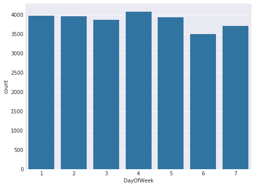

```python
plt.figure(figsize=(8,6))
base_color = sb.color_palette()[0]
sb.countplot(data = f_data, x = 'DayOfWeek', color = base_color);
```

The fourth(Thursday) day is the most travelled day with more than 4000 flights.

```python
#Defining a function for plotting bargraph

def barplot(data, var, dimens,xticks_angle, title, plot_lables):
    #plt.figure(figsize=(8,6))
    dims = (dimens[0], dimens[1])
    fig, ax = plt.subplots(figsize=dims)
    base_color = sb.color_palette()[0]
    sb.set_style('darkgrid')
    sb.countplot(data = data, x = var[0], ax = ax, color = base_color).set(title=title)
    plt.xlabel(plot_lables[0]);
    plt.ylabel(plot_lables[1]);
    plt.xticks(rotation = xticks_angle)
    plt.show()
```

### Which quarter had more flights per quarter?

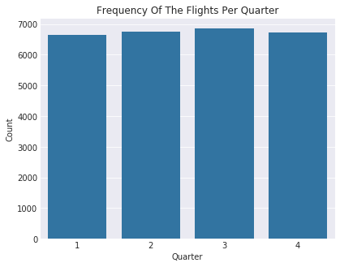

```python
barplot(f_data,['Quarter'],[6.5, 5],0,"Frequency Of The Flights Per Quarter",['Quarter','Count']);
```

The difference between them is not really significant, But the third quarter shows the highest flight frequency.

### Which year had most flights?

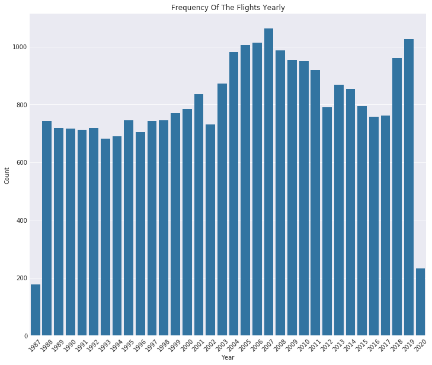

```python
barplot(f_data,['Year'],[12, 10],45,"Frequency Of The Flights Yearly",['Year','Count']);
```

2007 had the most number of flights, more than 1000 flights.

### Which month had most flights?

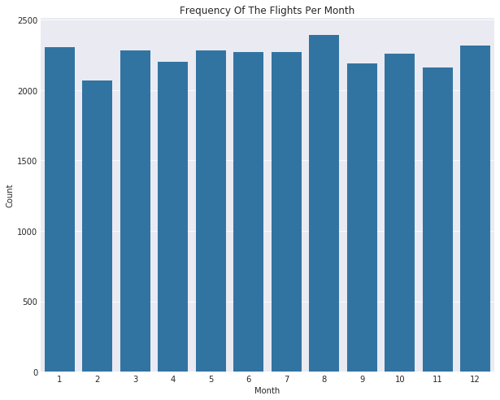

```python
barplot(f_data,['Month'],[10, 8],0,"Frequency Of The Flights Per Month",['Month','Count']);
```

August had the most flights and the difference is not really that big because all months had more than 2000 flights.

### Which cancellation code has the highest percentage?

```python
# changing the data type from object to category
f_data['CancellationCode'] = f_data['CancellationCode'].astype('category')
```

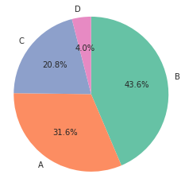

```python
#creating a dataframe only with the CancellationCode and counts
code = f_data['CancellationCode'].value_counts()
colors = sb.color_palette('Set2')
plt.pie(code, labels = code.index, colors = colors,startangle = 90,
        counterclock = False,autopct="%.1f%%")

plt.axis('square')
plt.show();
```

Weather had the highest percentage for flight cancellations

### Checking the Distribution of delays : DepDelay

```python
# Creating a function with log scale
def hist(var,xlabel, ylabel):
    plt.figure(figsize=[12, 6.5])
    bins = 10 ** np.arange(2.2, np.log10(f_data[var].max())+0.02, 0.02)
    plt.hist(data = f_data, x = var , bins = bins)
    plt.xscale('log')
    plt.xticks([300, 500, 1e3, 2e3], [300, 500,'1k', '2k'])
    plt.xlabel(xlabel)
    plt.ylabel(ylabel);
```

```python
hist('DepDelay','Depature Delay (min)', 'Count');
```

[output not shown]

### Checking the Distribution of delays : ArrDelay

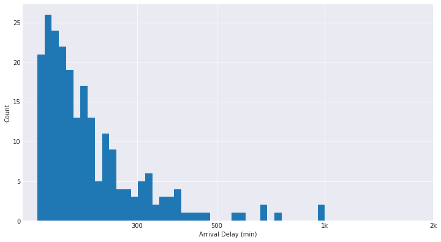

```python
hist('ArrDelay','Arrival Delay (min)', 'Count');
```

### Checking the Distribution of delays : Distance

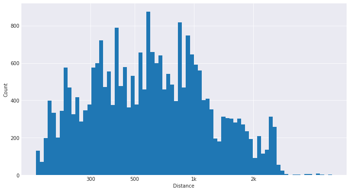

```python
hist('Distance', 'Distance', 'Count');
```

### Discuss the distribution(s) of your variable(s) of interest. Were there any unusual points? Did you need to perform any transformations?

On histograms the the normal scale was not depicting the data appropriately because of the scewenes of the data. So had to use log.

### Of the features you investigated, were there any unusual distributions? Did you perform any operations on the data to tidy, adjust, or change the form of the data? If so, why did you do this?

I changed the delay variables to remove the Nulls and replace with 0 because they giving me errors when plotting. I changed the Cancelled variable to string from float so that it can be more meaniful when reading the charts, because the yes and no were initially represented by 1.0 and 0.0 respectively.

## Bivariate Exploration

### How strong is the relationship between the DepDelay and CarrierDelay

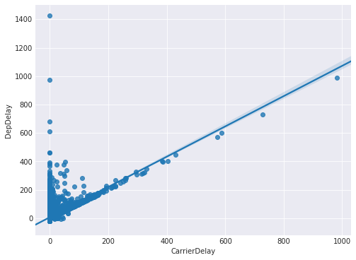

```python
plt.figure(figsize=(8,6))
CarrierDep = f_data[['DepDelay', 'CarrierDelay']]
# cutting out outlies from DepDelay
CarrierDep = CarrierDep[CarrierDep['CarrierDelay'] < 1000]
sb.regplot(data = CarrierDep, x = 'CarrierDelay', y = 'DepDelay');
```

```python
# checking how strong the correlation with figures as well
CarrierDep[['CarrierDelay','DepDelay']].corr()
```

|  | CarrierDelay | DepDelay |
| --- | --- | --- |
| CarrierDelay | 1.000000 | 0.520215 |
| DepDelay | 0.520215 | 1.000000 |

The relationship between CarrierDelay and DepDelay is fairly positive but not strong.

### How strong is the relationship between DepDelay and ArrDelay

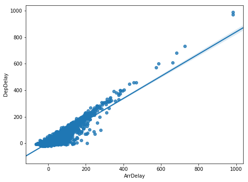

```python
plt.figure(figsize=(8,6))
ArrDep = f_data[['ArrDelay', 'DepDelay']]
# cutting out outlies from DepDelay
ArrDep = ArrDep[ArrDep['DepDelay'] < 1200]
sb.regplot(data = ArrDep, x = 'ArrDelay', y = 'DepDelay');
```

```python
# checking how strong the correlation with figures as well
ArrDep[['ArrDelay','DepDelay']].corr()
```

|  | ArrDelay | DepDelay |
| --- | --- | --- |
| ArrDelay | 1.000000 | 0.919914 |
| DepDelay | 0.919914 | 1.000000 |

The correlation is strong and positve, ArrDelay is affected by DepDelay

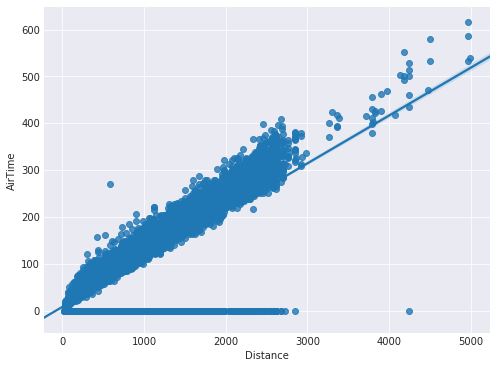

```python
plt.figure(figsize=(8,6))
ArrDep = f_data[['ArrTime', 'Distance']]
sb.regplot(data = f_data, x = 'Distance', y = 'AirTime');
```

```python
# checking how strong the correlation with figures as well
f_data[['AirTime','Distance']].corr()
```

|  | AirTime | Distance |
| --- | --- | --- |
| AirTime | 1.000000 | 0.777628 |
| Distance | 0.777628 | 1.000000 |

The relationship between AirTime and Distance is positive and strong.

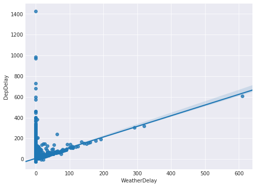

```python
plt.figure(figsize=(8,6))
sb.regplot(data = f_data, x = 'WeatherDelay', y = 'DepDelay');
```

```python
f_data[['WeatherDelay','DepDelay' ]].corr()
```

|  | WeatherDelay | DepDelay |
| --- | --- | --- |
| WeatherDelay | 1.000000 | 0.202997 |
| DepDelay | 0.202997 | 1.000000 |

### How strong is the relationship between NASDelay and ArrDelay

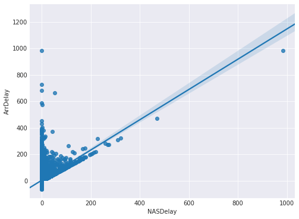

```python
plt.figure(figsize=(8,6))
sb.regplot(data = f_data, x = 'NASDelay', y = 'ArrDelay');
```

```python
f_data[['NASDelay','ArrDelay' ]].corr()
```

|  | NASDelay | ArrDelay |
| --- | --- | --- |
| NASDelay | 1.00000 | 0.42517 |
| ArrDelay | 0.42517 | 1.00000 |

### Checking if cancellation of flights was also caused by distance

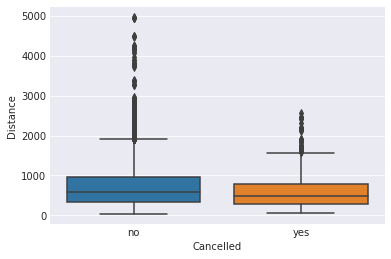

```python
sb.boxplot(data = f_data, x = 'Cancelled', y = 'Distance');
```

It shows that people cancelling their trips had nothing to do with distance

```python
#Defining functions fro plotting Lineplots and scatter plots
def plot(data,cols,kind,figprams, labels,title):
    data.plot(x=cols[0], y=cols[1], kind=kind, figsize=(figprams[0],figprams[1]))
    plt.xlabel(labels[0])
    plt.ylabel(labels[1])
    plt.title(title)
    plt.show()
```

```python
#Defining function for data aggregation
def aggregatedData(dataFrame,xCol,yCol):
    years = dataFrame[xCol].unique()
    countByYear = []
    for year in years:
        year_df = dataFrame[dataFrame[xCol]==year]
        count = len(year_df.index)
        countByYear.append((year, count))
    countByYearDF = pd.DataFrame(countByYear, columns=[xCol,yCol]).sort_values(xCol).reset_index().drop(['index'], axis=1)
    return countByYearDF
```

```python
#Defining function for creating subplots
def subplotsDiffData(data1,data2,kinds,plot1labels,plot2labels):
    #Subplots for
    fig = plt.figure() # create figure
    ax0 = fig.add_subplot(1, 2, 1)
    ax1 = fig.add_subplot(1, 2, 2)
    # Subplot 1: line plot
    data1.plot(x=plot1labels[0], y=plot1labels[1],kind=kinds[0], figsize=(20, 6), ax=ax0) # add to subplot 1
    ax0.set_title('')
    ax0.set_xlabel(plot1labels[0])
    ax0.set_ylabel(plot1labels[1])
    # Subplot 2: Line plot
    data2.plot(x=plot2labels[0], y=plot2labels[1],kind=kinds[1], figsize=(20, 6), ax=ax1) # add to subplot 2
    ax1.set_title ('')
    ax1.set_xlabel(plot2labels[0])
    ax1.set_ylabel(plot2labels[1])
    plt.show()
```

### Checking the the most affected month by arrival delay and departure delay

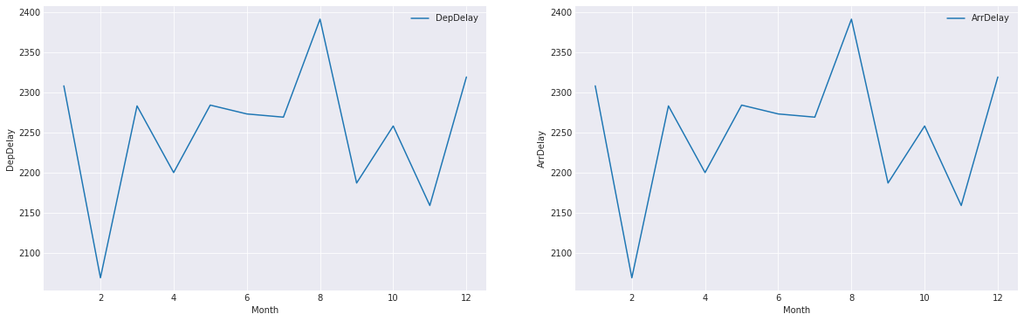

```python
month_arr = aggregatedData(f_data,'Month','DepDelay')
month_dep = aggregatedData(f_data,'Month','ArrDelay')
subplotsDiffData(month_arr,month_dep,['line','line'],['Month','DepDelay'],['Month','ArrDelay'])
```

### Checking the the most affected year by arrival delay and departure delay

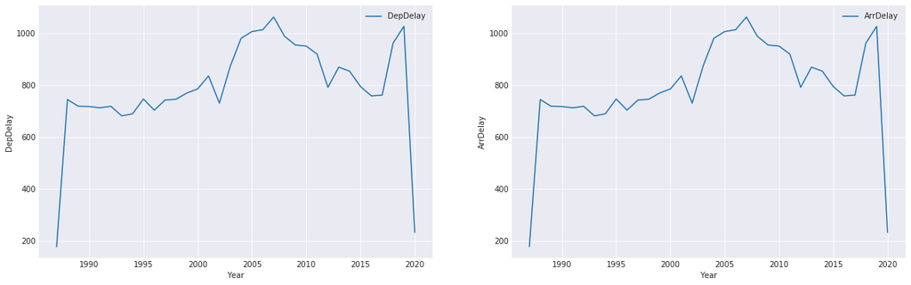

```python
year_arr = aggregatedData(f_data,'Year','DepDelay')
year_dep = aggregatedData(f_data,'Year','ArrDelay')
subplotsDiffData(year_arr,year_dep,['line','line'],['Year','DepDelay'],['Year','ArrDelay'])
```

```python
#Defining a function for plotting bargraph
base_color = sb.color_palette()[0]
def barrplot(data,var,dimens,shape,plot_type,xticks_angle,title,plot_lables):
    base_color = sb.color_palette()[0]
    dims = (dimens[0], dimens[1])
    fig, ax = plt.subplots(figsize=dims)
    sb.set_style('darkgrid')
    if plot_type.lower() == "u":
        if shape.lower() == "v":
            sb.countplot(data=data, x=var[0],ax = ax, color = base_color).set(title=title)
        else:
            sb.countplot(data=data, y=var[0],ax = ax, color = base_color).set(title=title)
    elif plot_type.lower() == "b":
        if shape.lower() == "v":
            sb.barplot(data=data, x=var[0],y=var[1],color=base_color).set(title=title)
        else:
            sb.barplot(data=data, x=var[1],y=var[0],color=base_color).set(title=title)

    plt.xlabel(plot_lables[0]);
    plt.ylabel(plot_lables[1]);
    plt.xticks(rotation = xticks_angle)
    plt.show()
```

### Top 25 Orinin with NASDelay

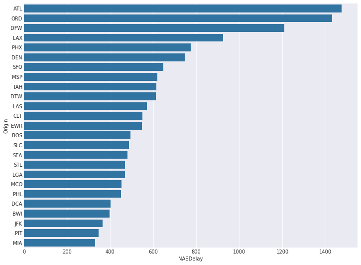

```python
depDelayByOrg = aggregatedData(f_data,"Origin","NASDelay")
depDelayByOrg.sort_values(by='NASDelay',inplace = True,ascending = False)
top25 = depDelayByOrg.head(25)
barrplot(top25,['Origin','NASDelay'], [12,9],"h",'b', 0,"",['NASDelay','Origin'])
```

### Talk about some of the relationships you observed in this part of the investigation. How did the feature(s) of interest vary with other features in the dataset?

CarrierDelay, WeatherDelay were likely to have the strongest positive correlationship but the data showed otherwise. The relationship is postive but not strong. Cancelled flights has nothing to do with distance.

### Did you observe any interesting relationships between the other features (not the main feature(s) of interest)?

CancellationCode shows that the most cancelled flights were caused by Weather(B).

## Multivariate Exploration

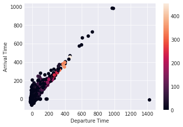

```python
#Checking the relationship between DepDelay, ArrDelay and LateAircraftDelay
plt.scatter(data = f_data, x = 'DepDelay', y = 'ArrDelay', c = 'LateAircraftDelay')
plt.colorbar()
plt.xlabel('Departure Time')
plt.ylabel('Arrival Time');
```

This shows that these three variables have a positive relationship.

### Checking which delay was popular over the years.

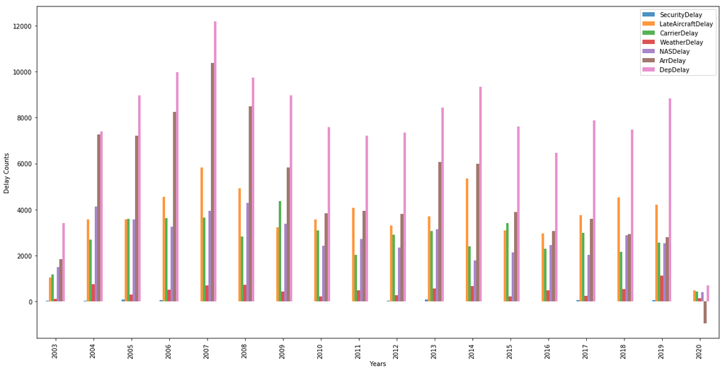

```python
delaysDF = f_data.filter(['Year','CarrierDelay','WeatherDelay','NASDelay','SecurityDelay','LateAircraftDelay', 'ArrDelay', 'DepDelay'], axis=1)
delaysDF = delaysDF.groupby('Year')['SecurityDelay','LateAircraftDelay','CarrierDelay','WeatherDelay','NASDelay', 'ArrDelay', 'DepDelay'].sum()
ax = delaysDF.loc[2003:].plot(kind='bar',alpha=0.8, figsize=(20,10 ))
ax.set_ylabel('Delay Counts')
ax.set_xlabel('Years')
sb.color_palette('colorblind');
```

Depature Delay had always been dominant over these years, followed by Arrival Delay only a few times when it interchanged with LateAirCraft Delay.

### Yearly flight cncellations

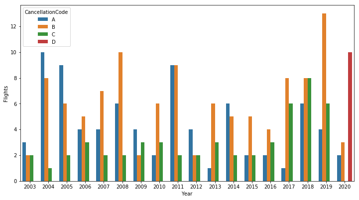

```python
#plt.title('Yearly Flight Cancelations')
plt.figure(figsize = (12,6.5))
#plt.title('Yearly Flight Cancelations')
bar_data = f_data.groupby(['Year','CancellationCode'])['Flights'].sum().reset_index()
sb.barplot(data=bar_data, x='Year',y='Flights',hue='CancellationCode')

plt.ylabel("Flights")
sb.color_palette('colorblind');
```

In most of the years Weather(B) had been causing flight cancellations most. Security(D) was never an issue until 2020 where it has the highest figure and it might have been triggered by corona virus.

### Talk about some of the relationships you observed in this part of the investigation. Were there features that strengthened each other in terms of looking at your feature(s) of interest?

Yes, the DepDelay, ArrDelay and LateAirCraftDelay shows that they really have a strong relationship.

### Were there any interesting or surprising interactions between features?

Security had never been a cause of flight cancellation in the period given except in the 2020 when it was actually the highest.